# Grapevine

Naitong Chen, Shirley Cui, Shannon Edie

# Data description

## Chardonnay

There are 40 samples in each of the chardonnay2019 and chardonnay2020 data set. The 40 samples consist of 8 samples from each of the 5 blocks. Among the 8 samples within each block, 4 samples of each treatment are included.

Both datasets contain 3 measurements of each sample with no missing data.

```
## [1] ï..sample.ID           row                    treatment
## [4] block                  subsample              X..of.clusters
## [7] yield..kg.             av.cluster.weight..kg.
## <0 rows> (or 0-length row.names)
```

## Merlot

There are 60 samples in each of the merlot2019 and merlot2020 data set. The 60 samples consist of 10 samples from each of the 6 blocks. Among the 10 samples within each block, 5 samples of each treatment are included.

There are 10 measurements that are common between the two merlot data sets. In addition, merlot2020 contains measures of fruitfulness, bloom, and brown seed color. merlot2019 contains measures of pruning weight and ravaz index.

In the merlot2019 data set, there are missing values from the measurement of veraison. In the merlot2020 data set, there are missing vales from the measurements of veraison, bloom, yield, cluster weight, berries/cluster, berry weight, berry Brix, berry TA, berry pH, and brown seed color.

```
##  [1] ï..Key          block           treatment       row
##  [5] subsample       SPAD            veraison        cluster.number
##  [9] yield           cluster.weight  berries.cluster berry.weight
## [13] berry.TA        berry.pH        berry.Brix      pruning.weight
## [17] Ravaz.index
## <0 rows> (or 0-length row.names)
```

```
##  [1] ï..Key           block            treatment        row
##  [5] subsample        fruitfulness     bloom            spad
##  [9] veraison         cluster.number   yield            cluster.weight
## [13] berries.cluster  berry.weight     berry.Brix       berry.TA
## [17] berry.pH         brown.seed.color
## <0 rows> (or 0-length row.names)
```

# Missing data in merlot2019 and merlot2020

## Veraison

We know from the client that the veraison column indicates the number days into August in each respective year when 50% of the berries on a given vine had changed to red. The missing entries are a result of the vines reaching 50% veraison on the first day of measurement. They are missing not at random (MNAR) as whether this value is missing for each vine is dependent on this particular value. More specifically, if any of the missing values were recorded, it must be negative.

While imputation seems like a reasonable approach, since we know these values must be negative, we can take the maximum between each imputed value and zero to produce complete data sets?

Percentage of missing for the veraison measure of merlot2019 and merlot2020 are shown below.

```
## [1] 0.4333333 0.1333333
```

## Bloom

Similar to veraison, the bloom column includes values that indicate the number of days into June in each respective year when 50% of the flowers on a given vine had started to bloom. The missing entries are a result of the vines reaching 50% bloom on the first day of measurement. They are also missing not at random (MNAR).

Again, we can consider taking the maximum between each imputed value and zero to produce complete data sets.

Percentage of missing for the bloom measure of merlot2020 is shown below.

```
## [1] 0.1166667
```

## Yield related measures

For all columns that contain missing values (yield, cluster weight, berries/cluster, berry weight), the reason for missing is that the vine had no yield. Even though these missing values depend on the measures of cluster number of their corresponding vines being zero, these yield related values are missing precisely because there are no yield. This is then also a case of missing not at random (MNAR).

Assigning these missing entries the value of zero seems plausible.

Percentage of missing for the yield related measures of merlot2020 is shown below.

```
## [1] 0.1166667
```

## Berry related measures

Due to the structure of the study, particularly the existence of blocking and replication, imputation seems to be the most reasonable approach to fill in the missing values.

Percentage of missing for the berry related measures of merlot2020 is shown below.

```
## [1] 0.1333333
```

## Question

In the merlot2020 data set, most of the vines that had no entries for bloom or veraison (implying earlier ripening) also had no yield. This is against my intuition. If anything, as observed in the other three data sets, early ripening may be associated with higher yield? What was the weather event that caused some of the vines to have no yield?

# Constructing complete data sets

We construct complete data sets using the approaches described above. Once these complete data sets are constructed, analysis can be done separately on each of the imputed data sets. Although we need to look into the necessity and methods to aggregate these results. We should also look into the order or columns to impute, as well as whether all responses should be used to predict the missing values.

For now, I have imputed with and without the yield related measures. We may consider more variants such as using only responses that are highly correlated.

Linear regerssions are used for imputation. There are a lot more available options specified on page 76 of https://cran.r-project.org/web/packages/mice/mice.pdf.

Note that the the columns of key, row and subsample are excluded from all imputations below.

## merlot2019

The imputed values of veraison for merlot2019 from the first imputed data set are shown below. Note they are all above zero, they will all be filled in with zero before the analysis.

```
##  [1] 21.715994 18.125289 16.773634 14.942121 19.471914 21.589641 21.486780
##  [8] 15.115459  8.349683 18.339226 20.047271 13.725877 21.528018  7.691104
## [15] 18.035914 20.088900 22.080232 11.933042 13.388718  2.451018  8.835080
## [22] 24.841542 25.660091 20.944922  9.503893 11.462480
```

## merlot2020

The first set of imputed values for merlot2020 using all responses are shown below.

```
## [1] "veraison"
```

```
## [1] 30.67912 30.34631 31.56788 30.22332 25.51688 28.10610 27.17114 28.72719
```

```
## [1] "berry Brix"
```

```
## [1] 27.28276 27.34771 25.86445 27.62986 28.48672 28.04230 27.84948 28.06373
```

```
## [1] "berry pH"
```

```
## [1] 3.519315 3.523890 3.232155 3.496757 3.630889 3.655843 3.511203 3.484332
```

```
## [1] "berry TA"
```

```
## [1] 6.349962 6.422805 8.139608 6.498603 5.441846 4.693712 6.532854 6.638227
```

```
## [1] "brown seed color"
```

```
## [1] 63.62264 63.88353 75.09464 64.83935 72.78476 73.82176 68.46240 68.89437
```

The first set of imputed values for merlot2020 not using yield related measures are shown below.

```
## [1] "veraison"
```

```
## [1] 32.35104 31.94097 31.91933 31.39454 27.36092 29.21802 25.75810 30.42609
```

```
## [1] "berry Brix"
```

```
## [1] 26.22747 26.31896 25.91935 26.55039 27.50730 26.92197 26.82877 27.06777
```

```
## [1] "berry pH"
```

```
## [1] 3.290631 3.298345 3.231982 3.272862 3.408987 3.421944 3.281947 3.258690
```

```
## [1] "berry TA"
```

```
## [1] 7.357714 7.404429 8.037524 7.580077 6.348228 5.812225 7.558876 7.710729
```

```
## [1] "brown seed color"
```

```
## [1] 79.30215 79.52354 76.95949 78.53604 89.29272 88.31270 84.29497 83.44413
```

Again the veraison values are all above zero, and so zero values will assigned before conducting the analysis.

Check out the imputed data sets in the code blocks!

## data preprocessing - PCA

# Check for correlations

## Chardonnay dataset

### chardonnay 2019

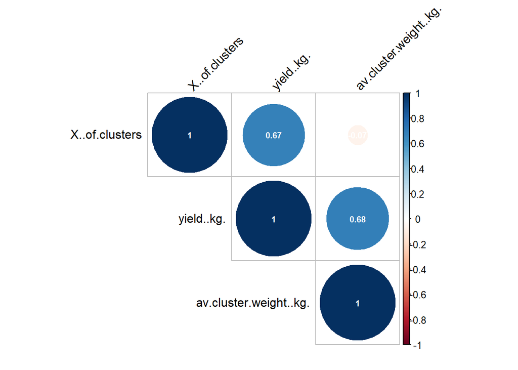

```r
chardonnay2019 %>%
  select(-1:-5) %>%
  cor() %>%
  corrplot(type = "upper", order = "hclust", tl.col = "black", tl.srt = 45, addCoef.col="white", number.cex=0.7)
```

### chardonnay 2020

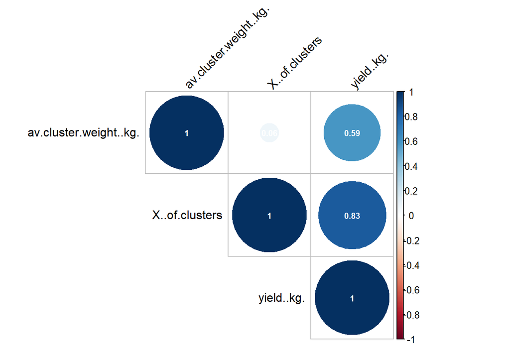

```r
chardonnay2020 %>%
  select(-1:-5) %>%
  cor() %>%
  corrplot(type = "upper", order = "hclust", tl.col = "black", tl.srt = 45, addCoef.col="white", number.cex=0.7)
```

Yield is found to be positively correlated with number of clusters.

### merlot 2019

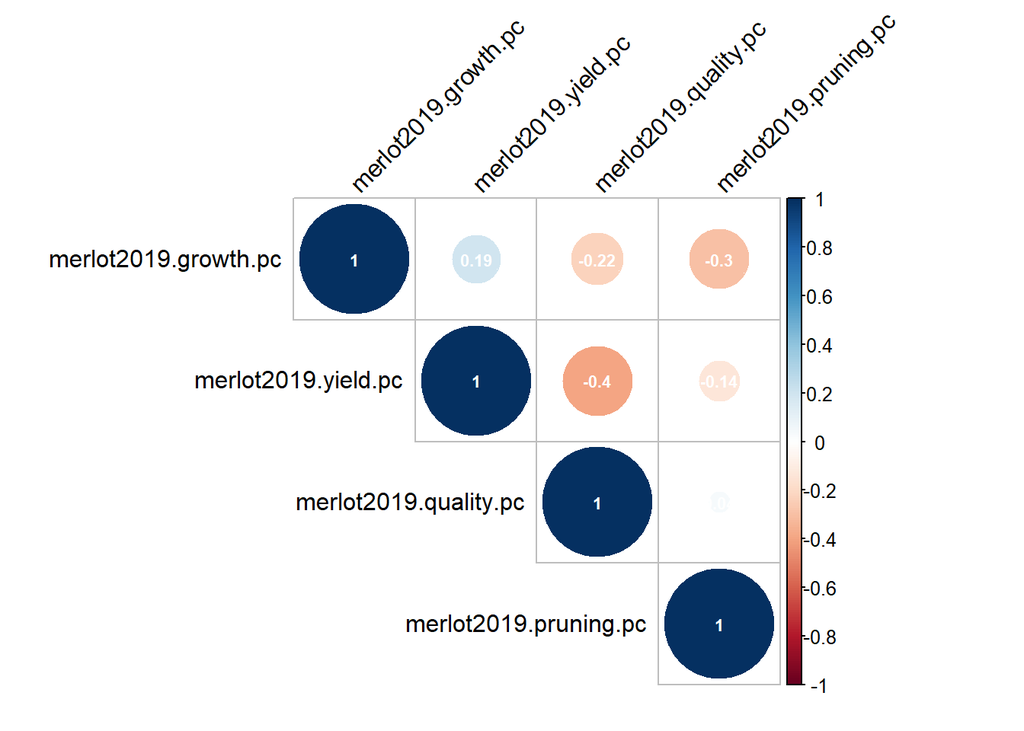

```r
merlot2019.pca %>%
  select(-1:-5) %>%
  cor() %>%
  corrplot(type = "upper", order = "hclust", tl.col = "black", tl.srt = 45, addCoef.col="white", number.cex=0.7)
```

### merlot 2020

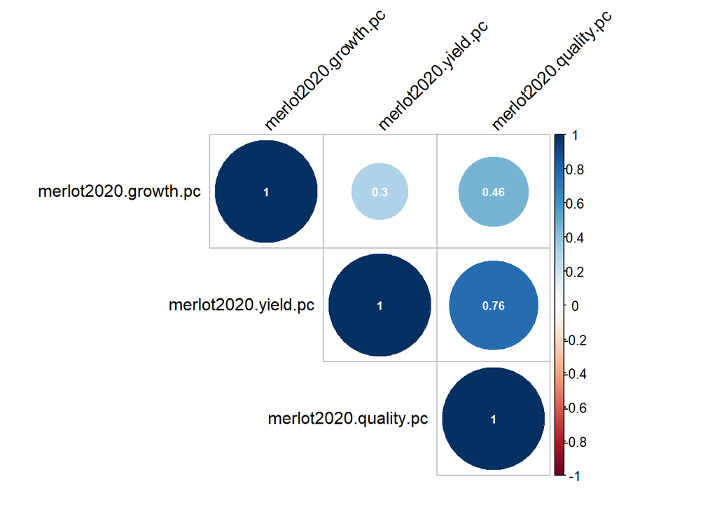

```r
merlot2020.pca %>%
  select(-1:-5) %>%
  cor() %>%
  corrplot(type = "upper", order = "hclust", tl.col = "black", tl.srt = 45, addCoef.col="white", number.cex=0.7)
```

## Check for assumption of ANOVA test: normality and equal variance

### Chardonnay 2019

1. table of mean and variance under control and treatment for each response variable

```r
chardonnay2019 %>%
  group_by(block, treatment) %>%
  summarise(var.num_of_cluster=var(X..of.clusters),
            mean.num_of_cluster=mean(X..of.clusters),
            var.yield=var(yield..kg.),
            mean.yield=mean(yield..kg.),
            var.cluster_weight=var(av.cluster.weight..kg.),
            mean.cluster_weight=mean(av.cluster.weight..kg.))
```

| block | treatment | var.num_of_cluster | mean.num_of_cluster | var.yield | mean.yield | var.cluster_weight | mean.cluster_weight |
| --- | --- | --- | --- | --- | --- | --- | --- |
| 1 | control | 41.58333 | 28.75 | 2.9934334 | 5.590526 | 0.0006004816 | 0.1928360 |
| 1 | heat | 24.91667 | 24.75 | 5.7176824 | 5.284351 | 0.0043685073 | 0.2092217 |
| 2 | control | 18.66667 | 38.00 | 1.3118024 | 7.609012 | 0.0021548831 | 0.2034579 |
| 2 | heat | 26.25000 | 30.25 | 8.3402586 | 7.144080 | 0.0045003894 | 0.2312906 |
| 3 | control | 22.00000 | 28.00 | 2.6102314 | 6.214215 | 0.0015320106 | 0.2217168 |
| 3 | heat | 99.66667 | 36.50 | 3.4153842 | 5.851342 | 0.0005988171 | 0.1611007 |
| 4 | control | 11.33333 | 36.00 | 0.6549582 | 6.191536 | 0.0007924376 | 0.1731682 |
| 4 | heat | 22.91667 | 30.25 | 1.1650369 | 5.817322 | 0.0015668517 | 0.1946832 |
| 5 | control | 4.00000 | 31.00 | 1.4450230 | 5.601866 | 0.0014713834 | 0.1807254 |
| 5 | heat | 198.25000 | 28.25 | 11.2973435 | 5.204972 | 0.0009869620 | 0.1793797 |

2. Visualization (side by side boxplots for each response variable)

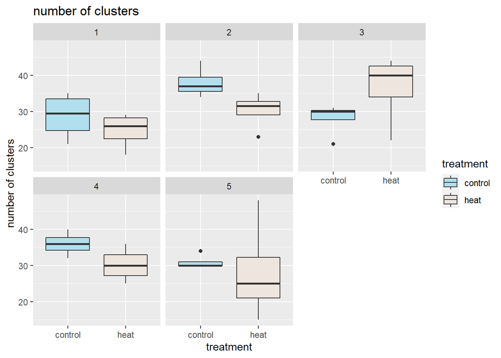

```r
## check assumptions of number of clusters
chardonnay2019 %>%
  ggplot(aes(x=treatment, y = X..of.clusters, fill=treatment))+
  scale_fill_manual(values=c("lightblue2", "seashell2"))+
  geom_boxplot()+
  labs(title = "number of clusters") +
  ylab("number of clusters")+
  facet_wrap(~block)
```

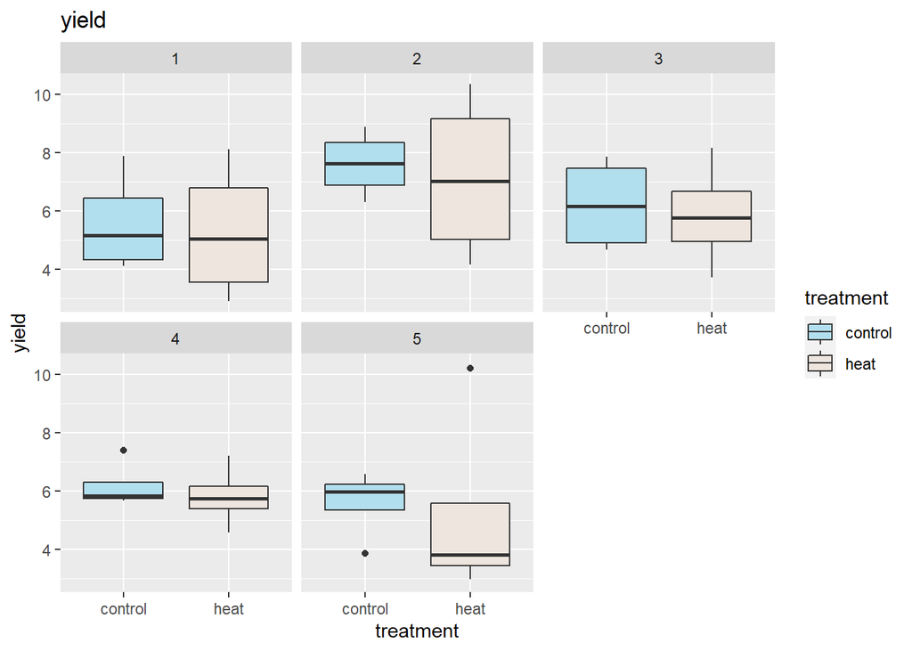

```r
## check assumptions of yield
chardonnay2019 %>%
  ggplot(aes(x=treatment, y = yield..kg., fill=treatment)) +
  scale_fill_manual(values=c("lightblue2", "seashell2"))+
  geom_boxplot()+
  labs(title = "yield") +
  ylab("yield")+
  facet_wrap(~block)
```

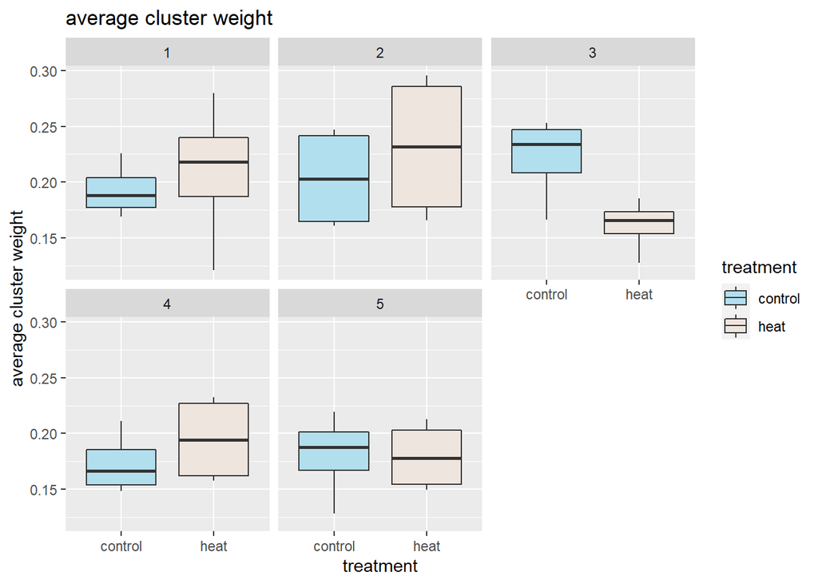

```r
## check assumptions for average cluster weight
chardonnay2019 %>%
  ggplot(aes(x=treatment, y = av.cluster.weight..kg., fill=treatment)) +
  scale_fill_manual(values=c("lightblue2", "seashell2"))+
  geom_boxplot()+
  labs(title = "average cluster weight") +
  ylab("average cluster weight")+
  facet_wrap(~block)
```

### Chardonnay 2020 1. table of mean and variance under control and treatment for each response variable

```r
chardonnay2020 %>%
  group_by(block, treatment) %>%
  summarise(var.num_of_cluster=var(X..of.clusters),
            mean.num_of_cluster=mean(X..of.clusters),
            var.yield=var(yield..kg.),
            mean.yield=mean(yield..kg.),
            var.cluster_weight=var(av.cluster.weight..kg.),
            mean.cluster_weight=mean(av.cluster.weight..kg.))
```

| block | treatment | var.num_of_cluster | mean.num_of_cluster | var.yield | mean.yield | var.cluster_weight | mean.cluster_weight |
| --- | --- | --- | --- | --- | --- | --- | --- |
| 1 | control | 83.583333 | 30.75 | 0.8180847 | 5.79400 | 0.0034564196 | 0.1988831 |
| 1 | heat | 1.583333 | 17.25 | 0.6986849 | 3.62875 | 0.0014749174 | 0.2089626 |
| 2 | control | 30.916667 | 35.25 | 2.4780323 | 7.71175 | 0.0003368401 | 0.2181853 |
| 2 | heat | 67.583333 | 29.25 | 5.6148753 | 7.25900 | 0.0087155766 | 0.2557268 |
| 3 | control | 275.000000 | 34.50 | 15.3377233 | 6.41200 | 0.0025215208 | 0.1778329 |
| 3 | heat | 9.666667 | 30.50 | 3.1462170 | 5.06250 | 0.0016991331 | 0.1628410 |
| 4 | control | 39.000000 | 23.50 | 1.8416837 | 4.22750 | 0.0002305304 | 0.1785992 |
| 4 | heat | 65.666667 | 27.50 | 5.7719887 | 5.64700 | 0.0024676484 | 0.2040394 |
| 5 | control | 12.250000 | 19.75 | 1.0575882 | 3.48625 | 0.0004342266 | 0.1741625 |
| 5 | heat | 32.250000 | 25.75 | 4.0398276 | 4.87075 | 0.0017454729 | 0.1850562 |

2. Visualization (side by side boxplots for each response variable)

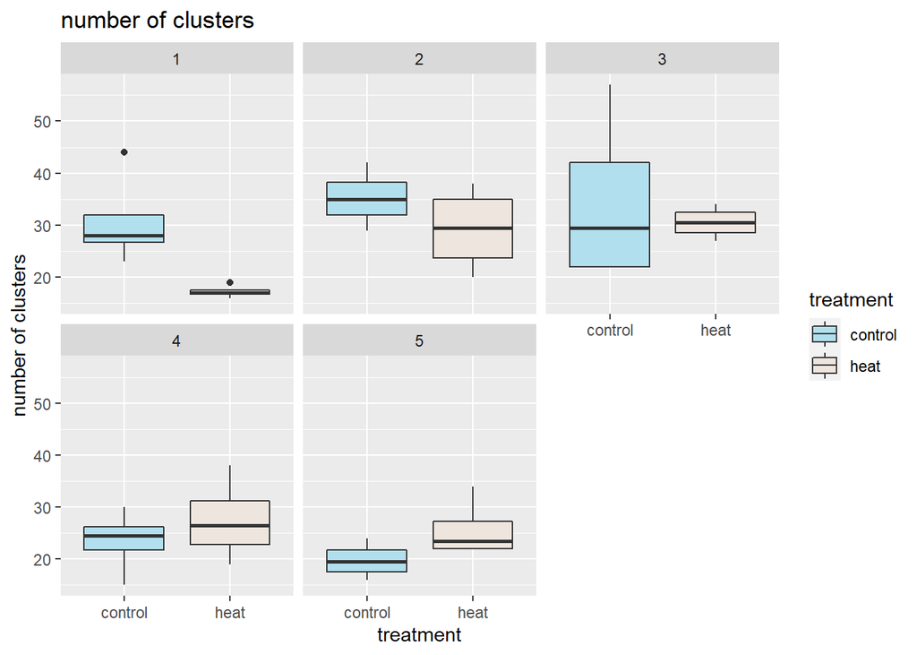

```r
## check assumptions of number of clusters
chardonnay2020 %>%
  ggplot(aes(x=treatment, y = X..of.clusters, fill=treatment))+
  scale_fill_manual(values=c("lightblue2", "seashell2"))+
  geom_boxplot()+
  labs(title = "number of clusters") +
  ylab("number of clusters")+
  facet_wrap(~block)
```

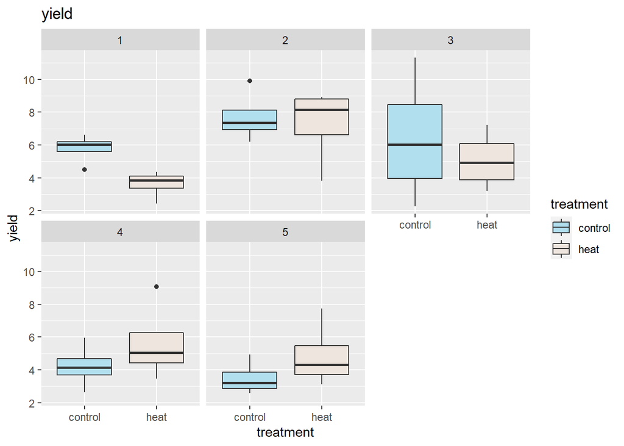

```r
## check assumptions of yield
chardonnay2020 %>%
  ggplot(aes(x=treatment, y = yield..kg., fill=treatment)) +
  scale_fill_manual(values=c("lightblue2", "seashell2"))+
  geom_boxplot()+
  labs(title = "yield") +
  ylab("yield")+
  facet_wrap(~block)
```

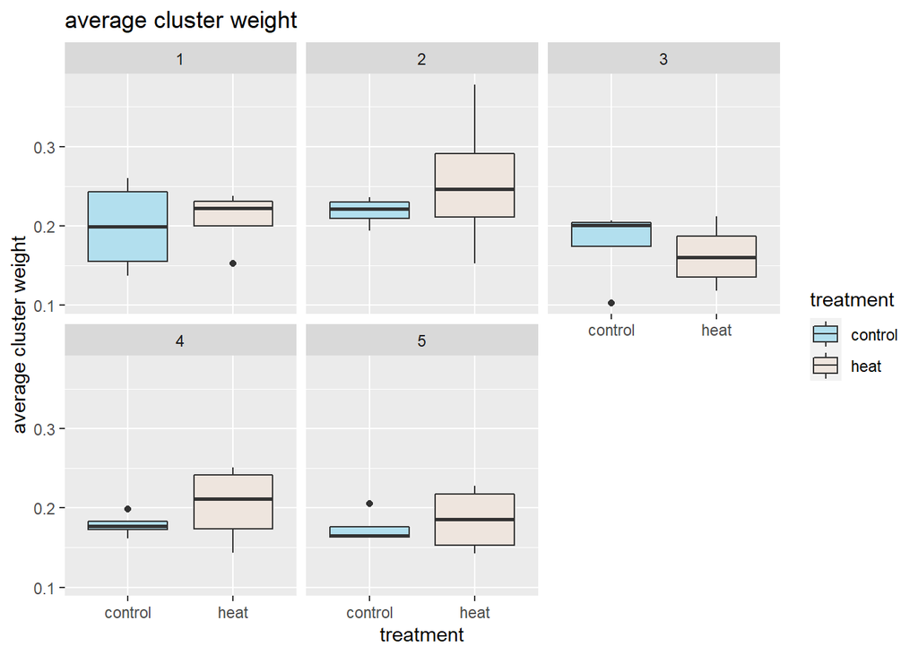

```r
## check assumptions for average cluster weight
chardonnay2020 %>%
  ggplot(aes(x=treatment, y = av.cluster.weight..kg., fill=treatment)) +
  scale_fill_manual(values=c("lightblue2", "seashell2"))+
  geom_boxplot()+
  labs(title = "average cluster weight") +
  ylab("average cluster weight")+
  facet_wrap(~block)
```

### merlot 2019 1. table of mean and variance under control and treatment for each response variable

```r
merlot2019.pca %>%
  group_by(block, treatment) %>%
  summarise(var.growth=var(merlot2019.growth.pc),
            mean.growth=mean(merlot2019.growth.pc),
            var.yield=var(merlot2019.yield.pc),
            mean.yield=mean(merlot2019.yield.pc),
            var.quality=var(merlot2019.quality.pc),
            mean.quality=mean(merlot2019.quality.pc),
            var.yield=var(merlot2019.pruning.pc),
            mean.yield=mean(merlot2019.pruning.pc))
```

| block | treatment | var.growth | mean.growth | var.yield | mean.yield | var.quality | mean.quality |
| --- | --- | --- | --- | --- | --- | --- | --- |
| 1 | control | 0.3529345 | -0.89172516 | 1.6878948 | -1.03701952 | 2.2815971 | 0.19381418 |
| 1 | heat | 0.4308397 | -0.76515576 | 0.9949224 | -0.52401263 | 0.2123755 | 0.68665317 |
| 2 | control | 0.8909363 | 0.64000506 | 2.0180720 | -0.97356662 | 3.4342048 | 1.08019454 |
| 2 | heat | 0.5966326 | 0.54817837 | 0.4680684 | 0.55550261 | 0.6623031 | 0.23076683 |
| 3 | control | 1.3856264 | -0.13859695 | 0.3177711 | 0.35316446 | 0.4051103 | 0.06207362 |
| 3 | heat | 0.2771511 | -0.10281612 | 1.4016894 | 0.90853578 | 0.5251420 | 0.25525161 |
| 4 | control | 0.6808972 | 0.02160971 | 0.8889011 | 0.65457915 | 0.7759795 | 0.02674300 |
| 4 | heat | 0.6710307 | 0.97077428 | 0.4533695 | -0.01784147 | 1.5382498 | -0.58429714 |
| 5 | control | 1.1976478 | 0.58738596 | 3.1585660 | 0.49441891 | 2.2934490 | -0.69215351 |
| 5 | heat | 0.7505324 | 0.68781881 | 1.1982888 | -0.67014015 | 1.5661741 | -1.97702054 |

[output cut: 2 more lines]

2. Visualization (side by side boxplots for each response variable)

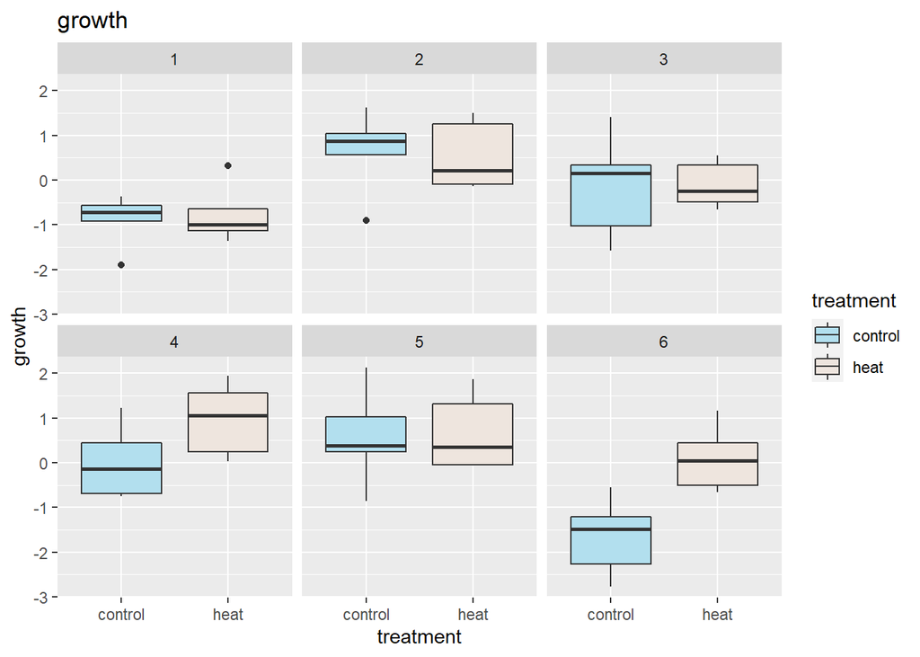

```r
ggplot(merlot2019.pca, aes(x=treatment, y = merlot2019.growth.pc, fill=treatment)) +
  scale_fill_manual(values=c("lightblue2", "seashell2"))+
  geom_boxplot()+
  labs(title = "growth") +
  ylab("growth")+
  facet_wrap(~block)
```

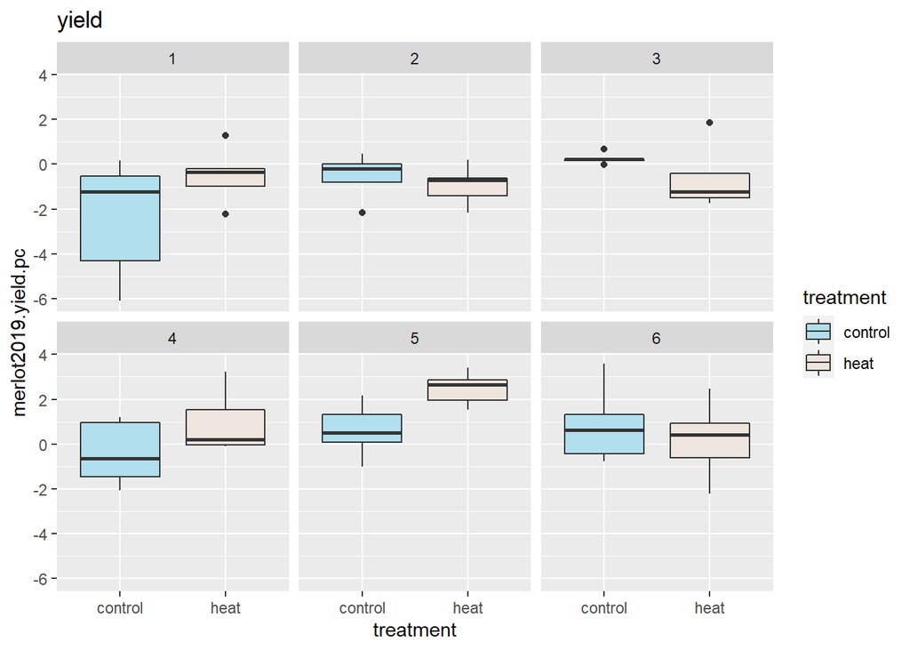

```r
ggplot(merlot2019.pca, aes(x=treatment, y = merlot2019.yield.pc, fill=treatment)) +
  scale_fill_manual(values=c("lightblue2", "seashell2"))+
  geom_boxplot()+
  labs(title = "yield") +
  facet_wrap(~block)
```

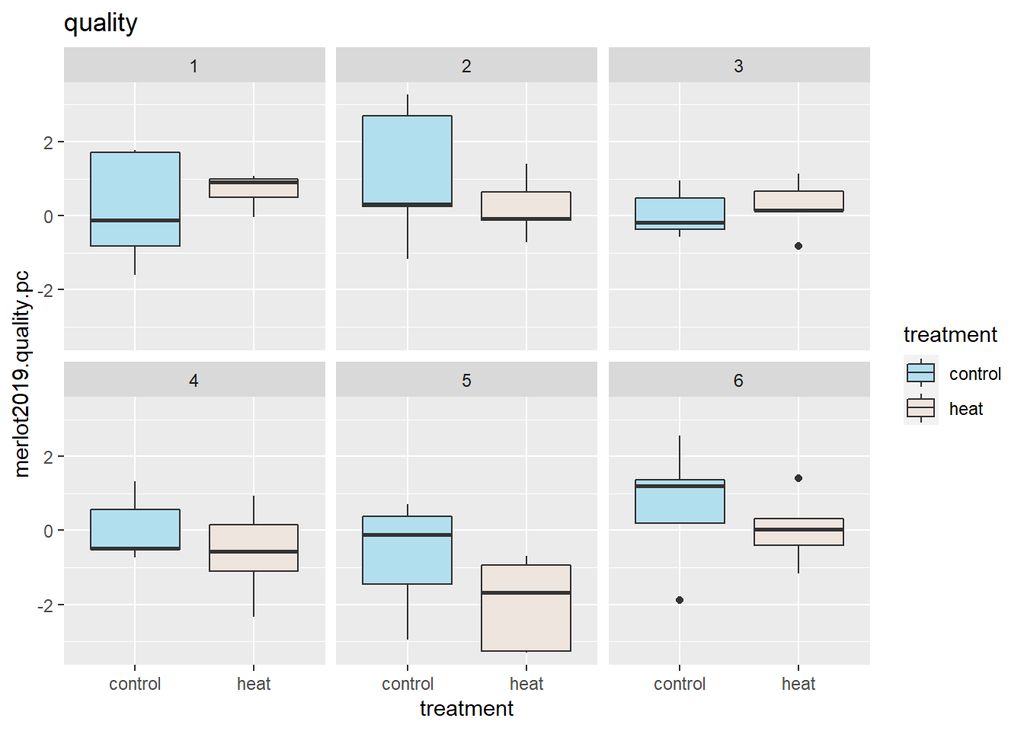

```r
ggplot(merlot2019.pca, aes(x=treatment, y = merlot2019.quality.pc, fill=treatment)) +
  scale_fill_manual(values=c("lightblue2", "seashell2"))+
  geom_boxplot()+
  labs(title = "quality") +
  facet_wrap(~block)
```

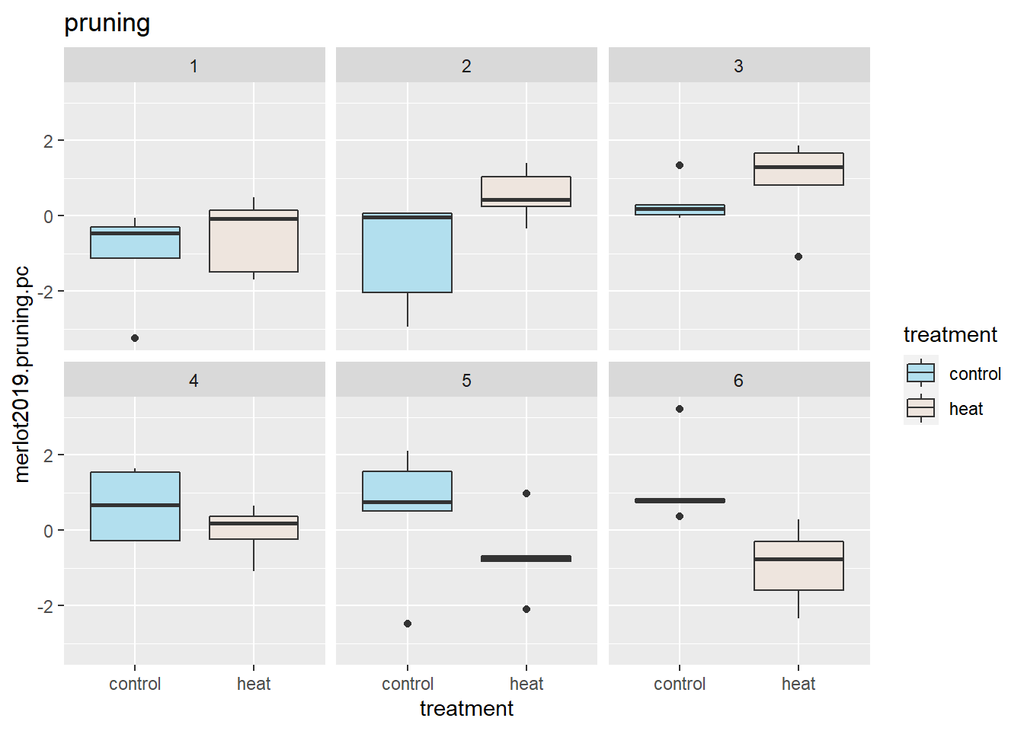

```r
ggplot(merlot2019.pca, aes(x=treatment, y = merlot2019.pruning.pc, fill=treatment)) +
  scale_fill_manual(values=c("lightblue2", "seashell2"))+
  geom_boxplot()+
  labs(title = "pruning") +
  facet_wrap(~block)
```

### merlot 2020

1. table of mean and variance under control and treatment for each response variable

```r
merlot2020.pca %>%
  group_by(block, treatment) %>%
  summarise(var.growth=var(merlot2020.growth.pc),
            mean.growth=mean(merlot2020.growth.pc),
            var.yield=var(merlot2020.yield.pc),
            mean.yield=mean(merlot2020.yield.pc),
            var.quality=var(merlot2020.quality.pc),
            mean.quality=mean(merlot2020.quality.pc))
```

| block | treatment | var.growth | mean.growth | var.yield | mean.yield | var.quality | mean.quality |
| --- | --- | --- | --- | --- | --- | --- | --- |
| 1 | control | 0.68791212 | -0.7638785 | 5.3317684 | -0.2968815 | 3.0649840 | -0.64382492 |
| 1 | heat | 0.19490177 | 0.1901401 | 1.8620651 | -1.1253404 | 0.1980199 | -0.40547322 |
| 2 | control | 1.71563413 | 0.6614463 | 5.5803768 | -2.0896457 | 2.3987092 | -0.69876840 |
| 2 | heat | 0.86464328 | -0.3928940 | 1.7827856 | -0.1897044 | 0.3150034 | 0.76595299 |
| 3 | control | 3.88027481 | 0.5665986 | 2.7402688 | 1.2940774 | 2.4861326 | 0.44621511 |
| 3 | heat | 0.07028263 | -0.4451762 | 5.4875379 | 0.9500231 | 5.1132838 | -0.02948561 |
| 4 | control | 0.09773783 | 0.1614389 | 1.7895042 | -0.4841246 | 0.7770976 | 0.30534869 |
| 4 | heat | 1.99315340 | 0.2043053 | 3.6055141 | 0.4694192 | 4.3076191 | 0.53961860 |
| 5 | control | 4.85903085 | 0.8302820 | 5.2641898 | 0.6372271 | 4.5322784 | 1.10002945 |
| 5 | heat | 1.57474635 | -0.8475142 | 0.7820638 | -0.4695183 | 2.2898455 | -0.51869129 |

[output cut: 2 more lines]

2. Visualization (side by side boxplots for each response variable)

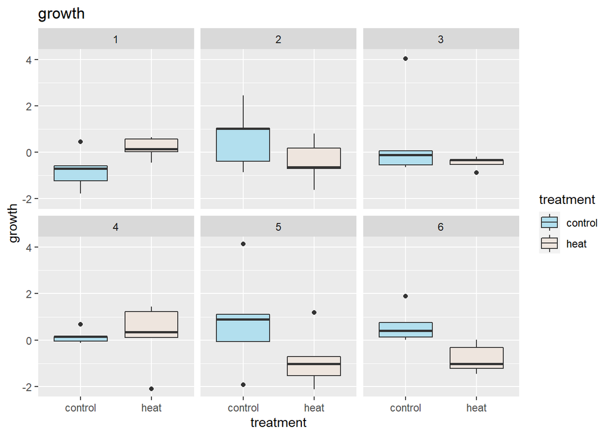

```r
ggplot(merlot2020.pca, aes(x=treatment, y = merlot2020.growth.pc, fill=treatment)) +
  scale_fill_manual(values=c("lightblue2", "seashell2"))+
  geom_boxplot()+
  labs(title = "growth") +
  ylab("growth")+
  facet_wrap(~block)
```

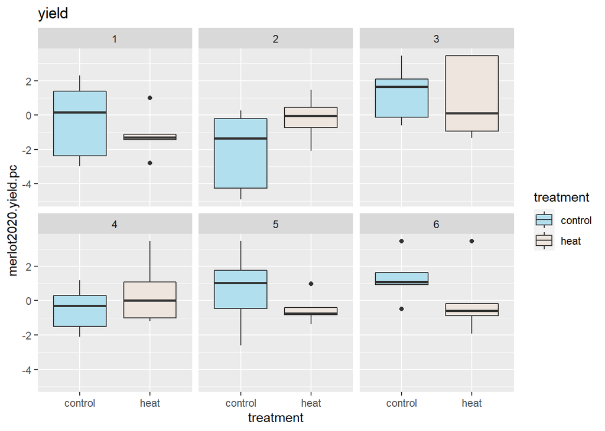

```r
ggplot(merlot2020.pca, aes(x=treatment, y = merlot2020.yield.pc, fill=treatment)) +
  scale_fill_manual(values=c("lightblue2", "seashell2"))+
  geom_boxplot()+
  labs(title = "yield") +
  facet_wrap(~block)
```

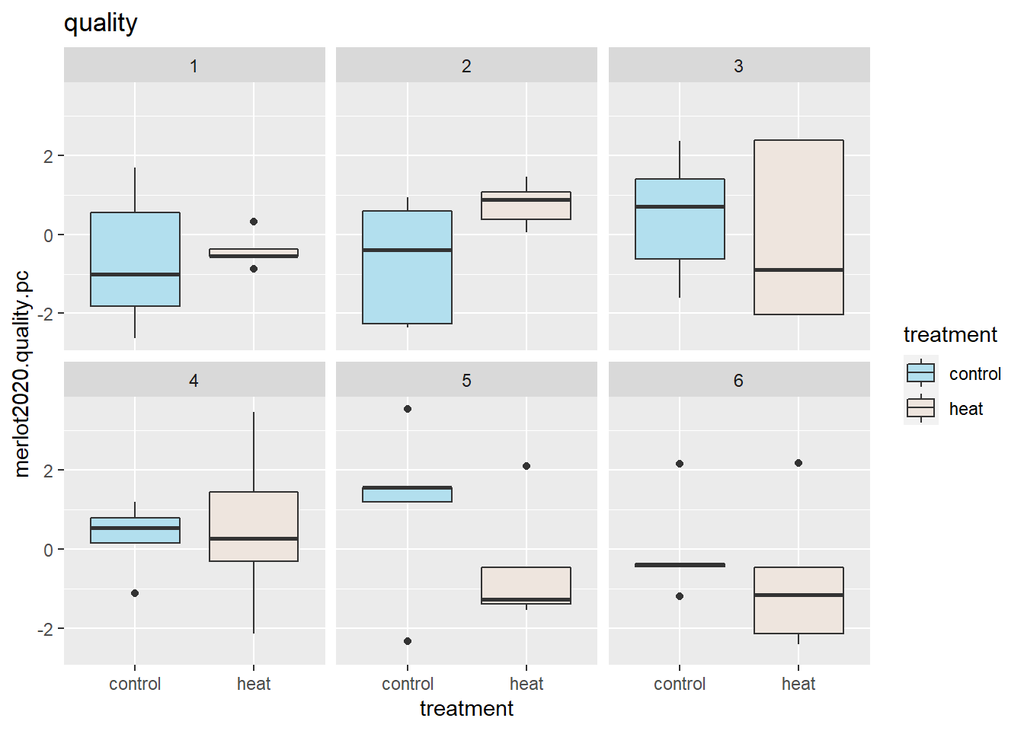

```r
ggplot(merlot2020.pca, aes(x=treatment, y = merlot2020.quality.pc, fill=treatment)) +
  scale_fill_manual(values=c("lightblue2", "seashell2"))+
  geom_boxplot()+
  labs(title = "quality") +
  facet_wrap(~block)
```

Below, wilcoxon rank tests can be performed to test whether the distribution in control and treatment groups are the same. (that would be a lot of tests… I only tried out the test for number of clusters in Char2019 for five blocks.) ### randomization test chardonnay 2019

```r
for (i in unique(chardonnay2019$block)){
  res=wilcox.test(chardonnay2019$X..of.clusters[chardonnay2019$block==i & chardonnay2019$treatment=="heat"],
                  chardonnay2019$X..of.clusters[chardonnay2019$block==i & chardonnay2019$treatment=="control"],
                  exact=FALSE)
  print(res)
}
```

```
##
##  Wilcoxon rank sum test with continuity correction
##
## data:  chardonnay2019$X..of.clusters[chardonnay2019$block == i & chardonnay2019$treatment == "heat"] and chardonnay2019$X..of.clusters[chardonnay2019$block == i & chardonnay2019$treatment == "control"]
## W = 5, p-value = 0.4705
## alternative hypothesis: true location shift is not equal to 0
##
##
##  Wilcoxon rank sum test with continuity correction
##
## data:  chardonnay2019$X..of.clusters[chardonnay2019$block == i & chardonnay2019$treatment == "heat"] and chardonnay2019$X..of.clusters[chardonnay2019$block == i & chardonnay2019$treatment == "control"]
## W = 1, p-value = 0.0606
## alternative hypothesis: true location shift is not equal to 0
##
##
##  Wilcoxon rank sum test with continuity correction
##
## data:  chardonnay2019$X..of.clusters[chardonnay2019$block == i & chardonnay2019$treatment == "heat"] and chardonnay2019$X..of.clusters[chardonnay2019$block == i & chardonnay2019$treatment == "control"]
## W = 13, p-value = 0.1913
## alternative hypothesis: true location shift is not equal to 0
##
##
##  Wilcoxon rank sum test with continuity correction
##
## data:  chardonnay2019$X..of.clusters[chardonnay2019$block == i & chardonnay2019$treatment == "heat"] and chardonnay2019$X..of.clusters[chardonnay2019$block == i & chardonnay2019$treatment == "control"]
## W = 2.5, p-value = 0.1465
## alternative hypothesis: true location shift is not equal to 0
##
##
##  Wilcoxon rank sum test with continuity correction
##
## data:  chardonnay2019$X..of.clusters[chardonnay2019$block == i & chardonnay2019$treatment == "heat"] and chardonnay2019$X..of.clusters[chardonnay2019$block == i & chardonnay2019$treatment == "control"]
## W = 4, p-value = 0.3005
## alternative hypothesis: true location shift is not equal to 0
```

QQ plot for number of clusters in chardonnary 2019 (for each block/treatment combo)

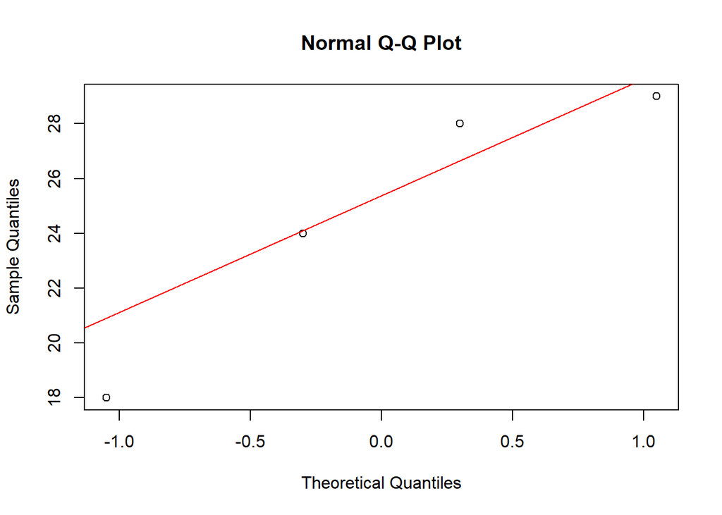

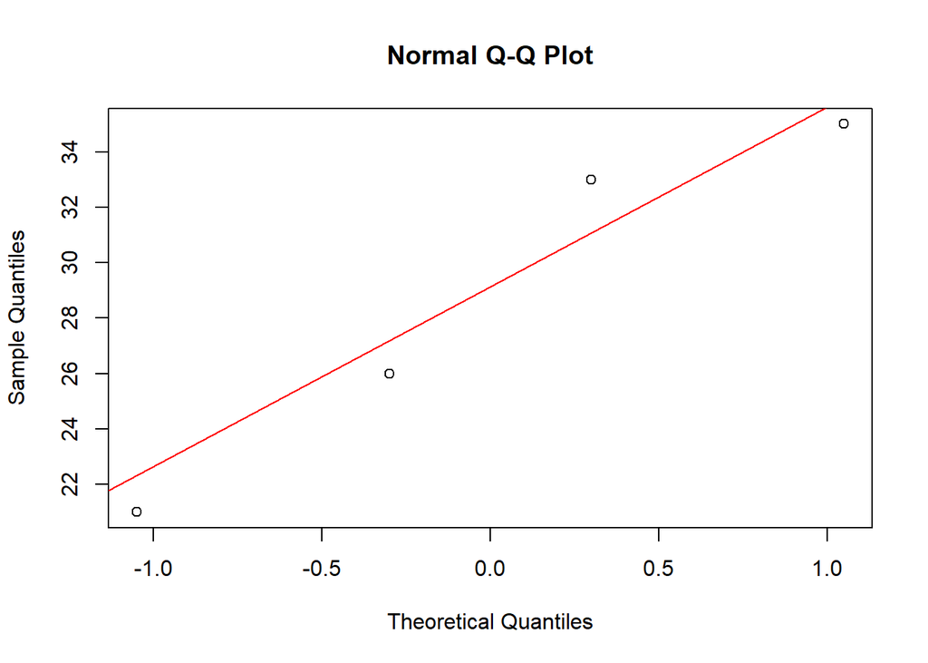

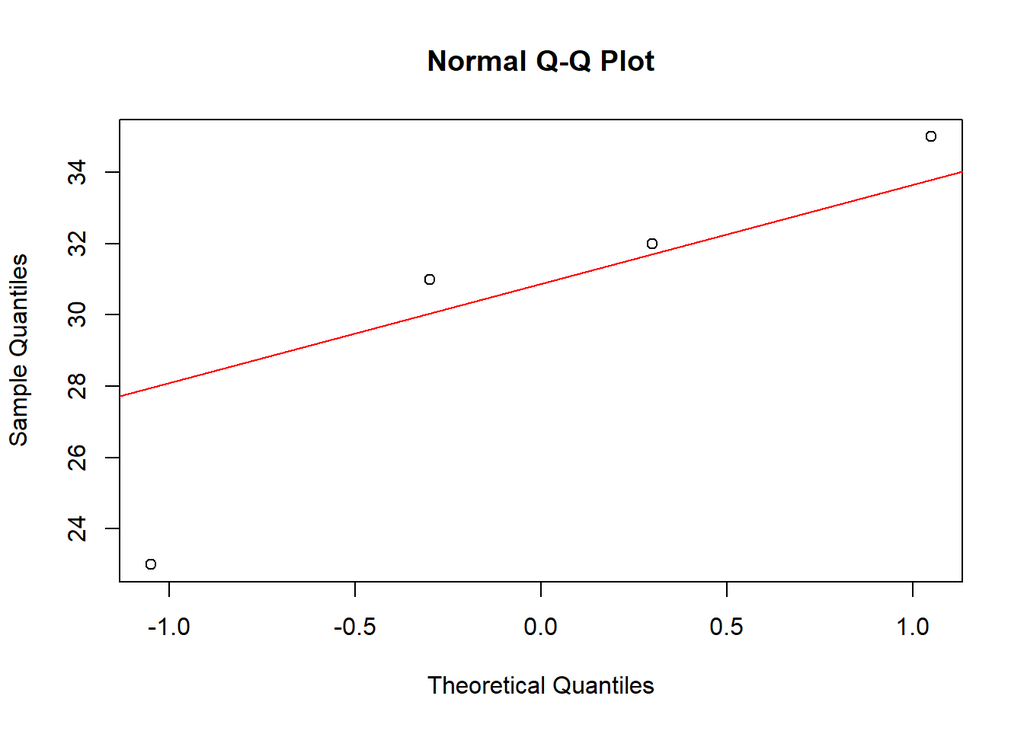

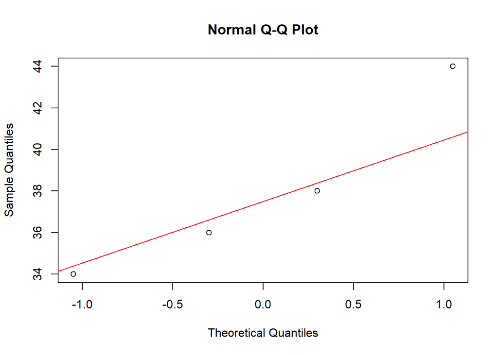

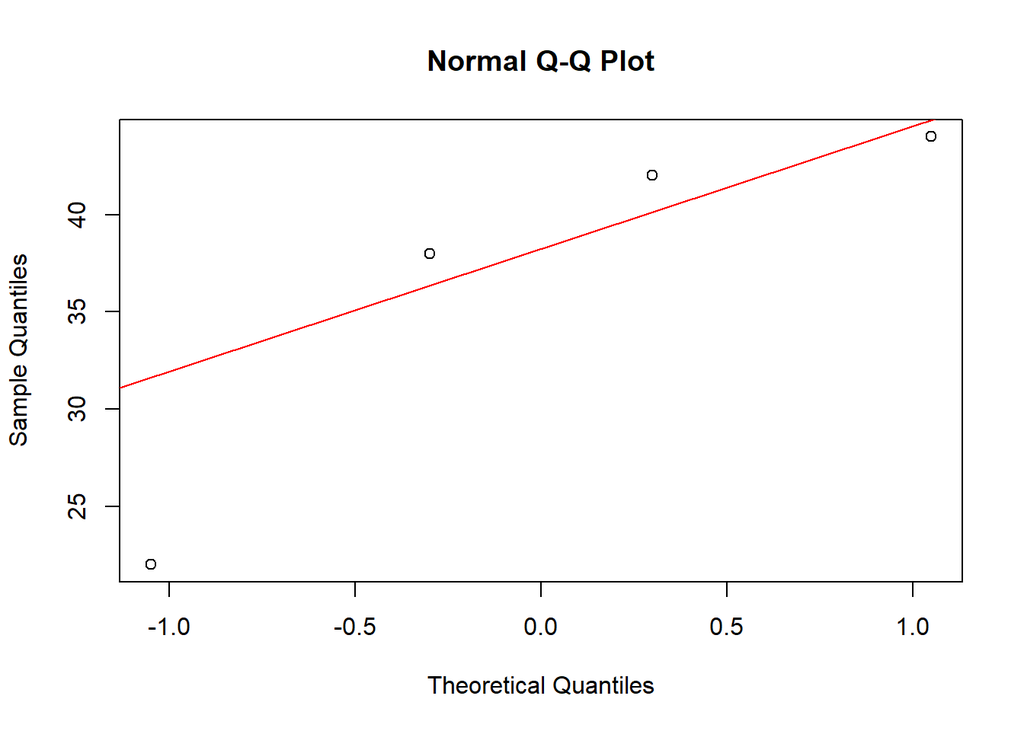

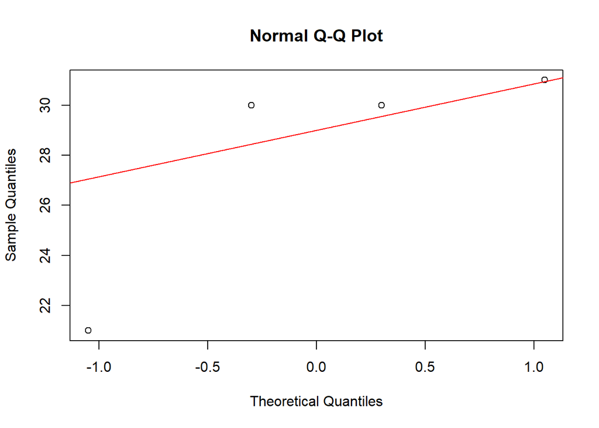

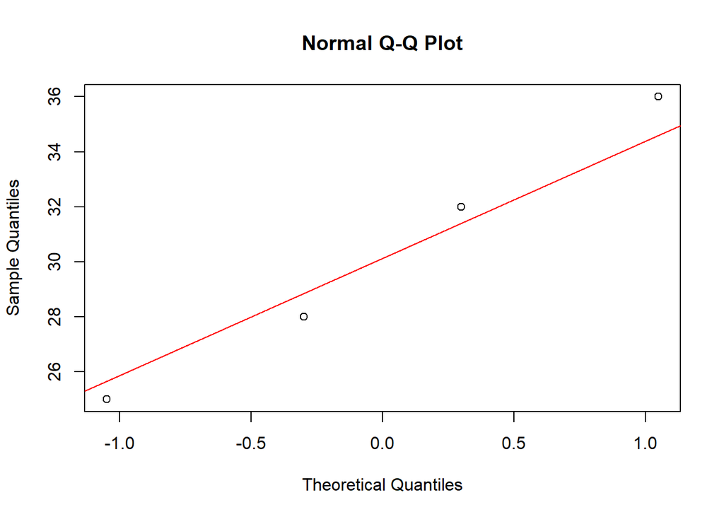

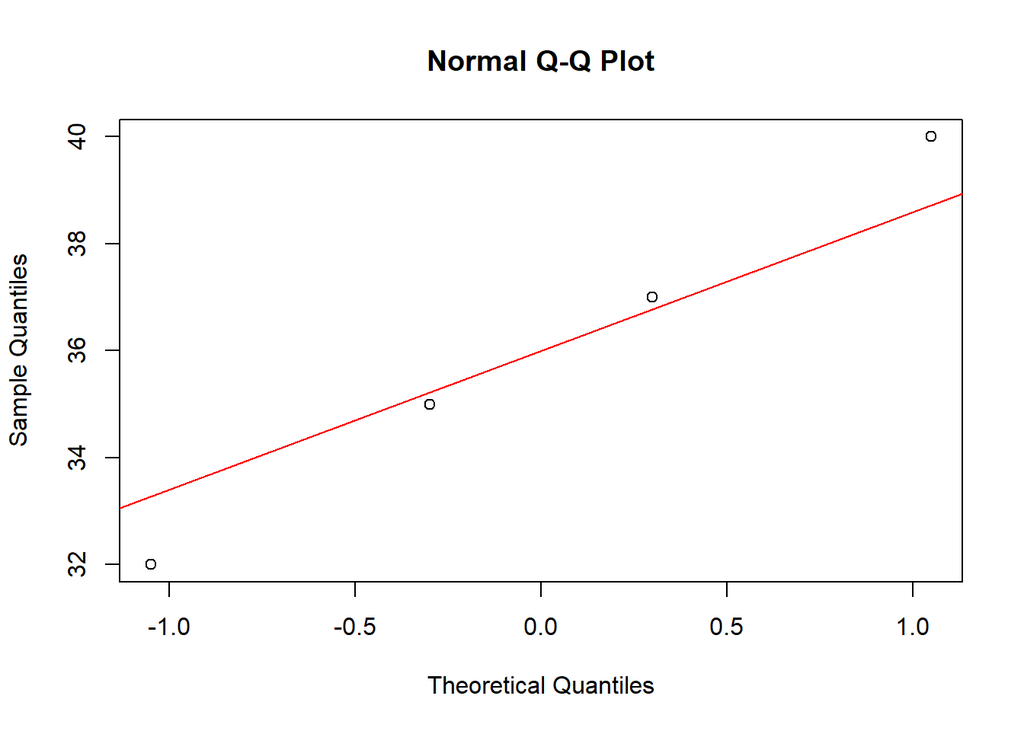

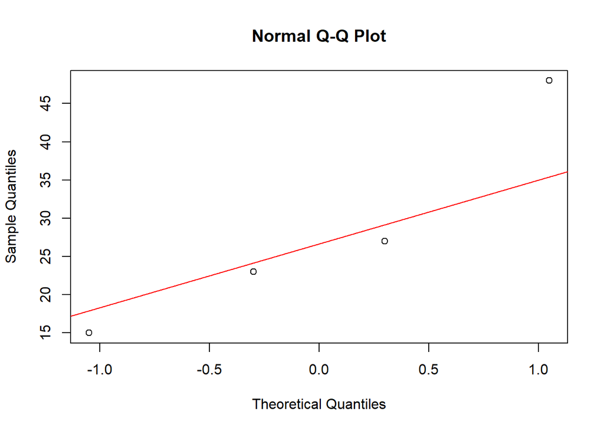

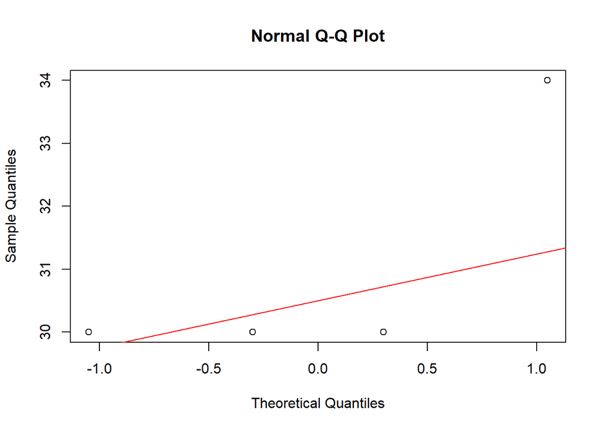

F test and randomization test for equal variance between treatments for each block in chardonnary 2019

```
## [1] "F test"
## [1] 0.6842653
## [1] "rand test"
## [1] 0.6428571
## [1] "F test"
## [1] 0.7860631
## [1] "rand test"
## [1] 0.7571429
## [1] "F test"
## [1] 0.2464142
## [1] "rand test"
## [1] 0.1714286
## [1] "F test"
## [1] 0.5777467
## [1] "rand test"
## [1] 0.6
## [1] "F test"
## [1] 0.009387336
## [1] "rand test"
## [1] 0.04285714
```

QQ plot for the growth PC in merlot 2020 (for each block/treatment combo)

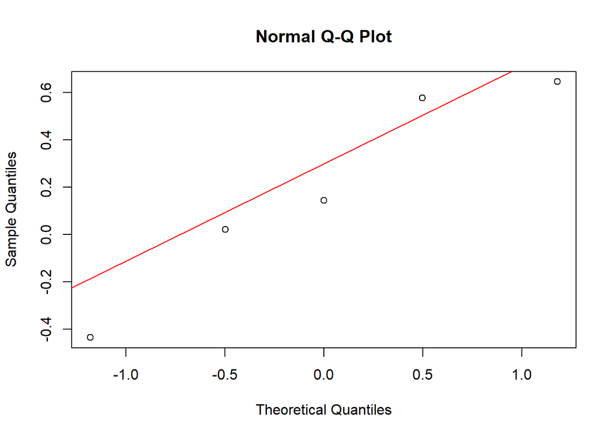

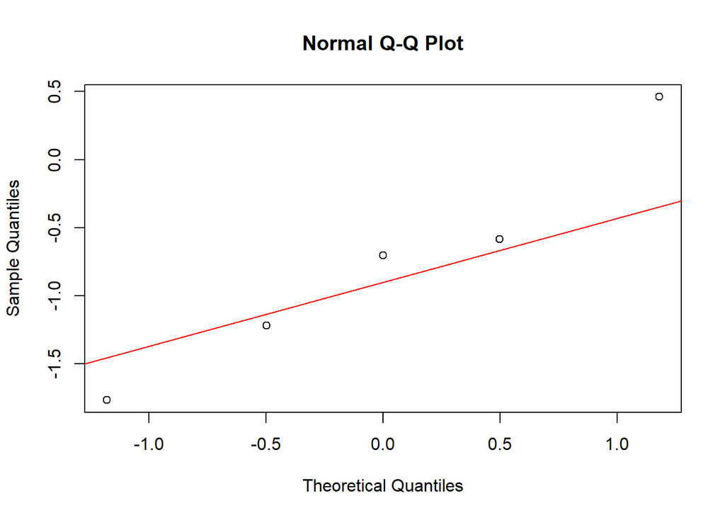

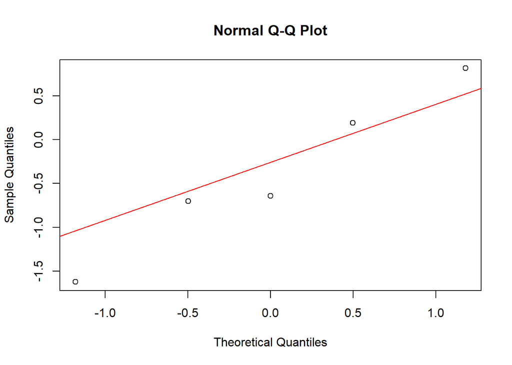